# Wortloses Ende - Bayerische Staatsoper

[figure not shown]

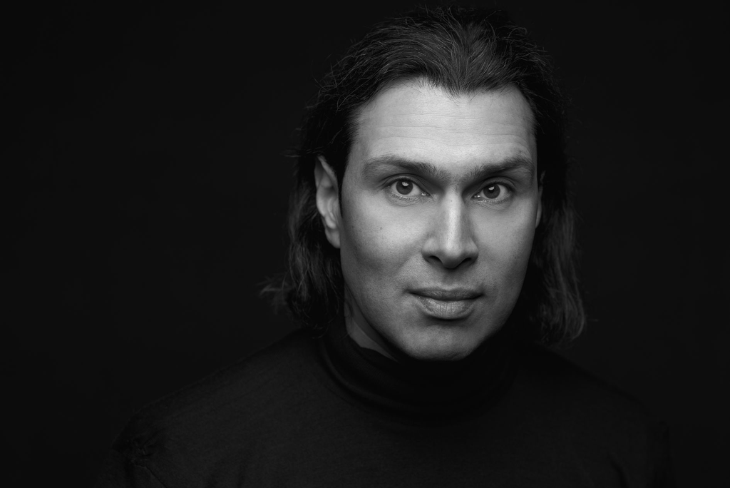

# Wortloses Ende

[Vladimir Jurowski](https://www.staatsoper.de/biographien/jurowski-vladimir) und [Dmitri Tcherniakov](https://www.staatsoper.de/biographien/tcherniakov-dmitri) kehren mit ihrer Inszenierung der Oper *Krieg und Frieden* zur Urfassung von [Sergej S. Prokofjew](https://www.staatsoper.de/biographien/prokofjew-sergej) zurück.

DAS GESPRÄCH FÜHRTE RUTH RENÈE REIF

*Dr. Ruth Renée Reif studierte in Wien Theaterwissenschaft und Kunstgeschichte und ist seit ihrer Promotion 1987 in München als freie Journalistin und Publizistin tätig. Zu ihren Veröffentlichungen zählen eine Biografie über die Sopranistin Karan Armstrong, ein historisches Porträt der Stuttgarter Philharmoniker sowie zahlreiche Gespräche mit Musikern, Schriftstellern und Philosophen – so auch immer wieder in Publikationen der Bayerischen Staatsoper wie Max Joseph oder Engelsloge. Auch für die Broschüre zum 500-Jahres-Jubiläum des Bayerischen Staatsorchesters 2023 hat sie einen Beitrag verfasst.*

*Maestro Jurowski, am Todestag von Sergej Prokofjew, hat an der Bayerischen Staatsoper das gewaltige Opernepos Krieg und Frieden Premiere. Was veranlasste zu dieser Wahl?*

Vor allem meine Liebe zur Musik Prokofjews und zu diesem Stück. Es gehört zu den wichtigsten Musiktheaterstücken des 20. Jahrhunderts. Zudem wurde es an der Bayerischen Staatsoper noch nie gespielt.

*Der Einmarsch der deutschen Armee 1941 bot Prokofjew den Anlass, Leo Tolstois Roman zu veropern…*

Prokofjews Oper ist seine Interpretation von Tolstois Roman. Dessen Titel bedeutet nämlich „Krieg und die Welt“ oder „Krieg und Gesellschaft“. Das Wort „Mir“ existierte im Altrussischen in zwei Schreibweisen, und Tolstois Wahl war eindeutig. Sein Roman stellt den Krieg der menschlichen Gesellschaft gegenüber. Prokofjew setzt aber die Akzente in seinem Stück etwas anders, und es gibt daher die saubere Trennung des Stücks in den Friedensteil und den Kriegsteil.

*Für Prokofjew war der Vaterländische Krieg von 1812 ein Weg, die Wirklichkeit seiner Zeit zu begreifen. Kann seine Oper heute ein Weg sein, unsere Zeit zu begreifen?*

Dass Tolstois Roman einen Weg aus der ausweglos erscheinenden Situation von heute weisen kann, dessen bin ich fast sicher. Mit Prokofjews Oper verhält es sich etwas komplizierter. Nach seiner Rückkehr in die Sowjetunion der 1930er-Jahre musste Prokofjew sich als sowjetischer Komponist der herrschenden Staatsideologie unterwerfen. Sonst riskierte er das Verbot seiner Werke und im schlimmsten Fall seine Freiheit oder sogar sein Leben.

*Was bedeutet das für seine Veroperung?*

Es ist kein Zufall, dass Prokofjew, der die Libretti immer selbst verfasste, jetzt seine zweite Frau Mira Mendelson einbezog. Sie war die Tochter zweier so genannter „Roter“ Professoren von der Moskauer Universität und die Frucht kommunistischer Erziehung. Gerade aus ihren Versen, besonders in den Chören der dramatischen Kriegsbilder, hört man den überbetonten Patriotismus, der mit Tolstoi nichts zu tun hat.

*Wäre ohne Mira Mendelsons Zuarbeit die Oper grundlegend anders?*

In seiner musikalischen Anlage schrieb Prokofjew ein eher lyrisches, intimes und sehr menschliches Werk. Vor allem der Friedensteil stellt einen modernen Versuch dar, lyrische Szenen nach dem Vorbild von Tschaikowskys *Eugen Onegin* zu schreiben. Seine Vertonungen der Prosatexte von Tolstoi stehen denn auch außerhalb jeder Kritik. Problematisch sind aber oft die hinzugefügten Chorgesänge, vor allem im zweiten Teil. Natürlich waren sie ein Schachzug, um das Wohlwollen der Machthabenden zu erwecken. Aber sie lassen das Werk auch als zum Teil „sowjetisch“ abstempeln.

# Das Wort „Mir“ existierte im Altrussischen in zwei Schreibweisen, und Tolstois Wahl war eindeutig. Sein Roman stellt den Krieg der menschlichen Gesellschaft gegenüber.

*Nun tauchte die Oper ab und an in westlichen Spielplänen auf. Wie ging man damit um?*

In der Tat stand man bereits bei früheren Aufführungen vor diesem Problem. Heute jedoch müssen wir viel rigoroser streichen. Das ist schon eine bittere Ironie, denn als der Regisseur Dmitri Tcherniakov und ich vor einigen Jahren zu unserem ersten Gespräch über die Oper zusammenkamen, war der erste Wunsch von uns beiden, sie komplett aufzuführen. Am 24. Februar aber begann der Krieg, und wir waren beide nahe daran, das Projekt abzusagen. Vor allem Tcherniakov verzweifelte über die Lage.

*Welchen Ausweg haben Sie gefunden?*

Wir haben eine Fassung erstellt, die sich auf die Protagonisten Natascha Rostowa, Andrei Bolkonski und Pierre Besuchow konzentriert und in der das kriegerische Geschehen nur eine Kulisse bildet. Im Kriegsteil wurden alle Bilder stark zusammengestrichen, eines fiel sogar komplett weg. Nur die intime Sterbeszene von Andrei haben wir unangetastet gelassen. Auf diese Weise können wir in der Oper die ewigen Fragen stellen, die uns bis heute beschäftigen. Insgesamt kann ich sagen, dass wir mit unseren Kürzungen zu Prokofjews erster Fassung zurückkehren.

*Ist das jene Fassung für zwei Abende?*

Prokofjew erstellte zwei Fassungen der Oper. Von der ersten Fassung wurde in Leningrad 1946 der erste Teil (Frieden) und 1948 der zweite Teil (Krieg) aufgeführt. Dann wurde das Stück verheerend kritisiert, vor allem aus ideologischer Sicht, und die erste Fassung wurde verboten. Später erarbeitete Prokofjew eine zweite Fassung, und zu der schrieb er einen Brief an die künftigen Dirigenten und Regisseure, in dem er erklärte, welche Szenen der Oper wegfallen könnten, wenn man sie an einem Abend spielen möchte. An diesem Brief orientierten wir uns.

*Prokofjew wollte „die großen Veränderungen betonen“, die in den Personen „aufgrund der ihrem Vaterland drohenden Gefahr“ vorgegangen seien. Können Sie das nachvollziehen?*

Nur teilweise. Die einzige Person, die sich im Laufe der Oper tatsächlich stark verändert, ist Pierre. Prokofjew bestand darauf, den Wortlaut von Tolstois inneren Monologen unangetastet zu lassen. So reden die Personen zwar über ihre Gefühle, aber sie handeln nicht oder fast nicht. Hätte Prokofjew länger gelebt, wäre sicher noch eine dritte Fassung entstanden. Man merkt, wie sehr er mit dem Schluss haderte.

*Für welchen Schluss haben Sie sich entschieden?*

Wir spielen den Urschluss aus der ersten Fassung, nur mit der Besonderheit, dass wir am Ende keinen Chor, sondern ein Bühnenorchester (eine Banda) haben. Die ist von Prokofjew als grandioser Kontrapunkt zum finalen Chor komponiert. Als ich diese Fassung Tcherniakov zeigte, sagte er mir, die besten Opern würden sowieso mit einem großen Orchesternachspiel enden. So entschieden wir uns für ein wortloses Finale. Die letzten gesungenen Worte werden von Pierres Monolog stammen, in dem er von der Notwendigkeit des Verstehens des Geschehenen spricht.

# Krieg und Frieden (Woina i mir)

[ZUR STÜCKSEITE](https://www.staatsoper.de/stuecke/krieg-und-frieden)

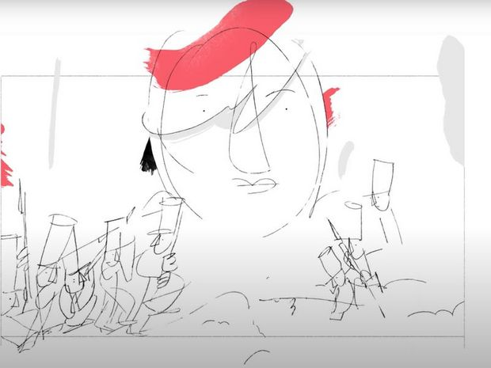

# Das Wichtigste auf einen Blick

[ZUR ÜBERSICHT](https://www.staatsoper.de/inhalte-home/krieg-und-frieden-das-wichtigste-auf-einen-blick)

[interactive chart not shown]